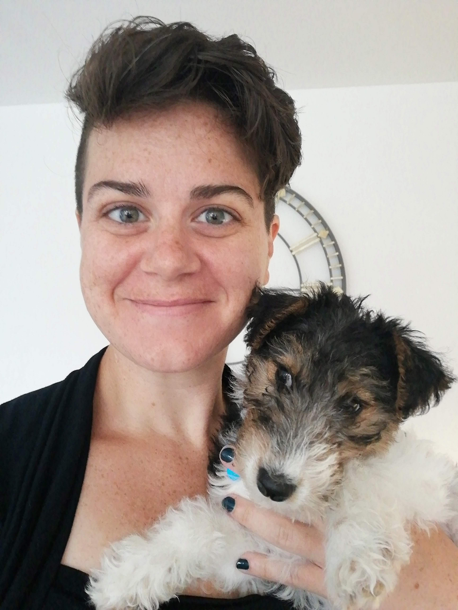

# Jennifer Mankin

[Github](https://github.com/drmankin/) [UoS Profile](https://profiles.sussex.ac.uk/p351056-jennifer-mankin)

Jennifer is a senior teaching-focused lecturer in Psychology at the University of Sussex. She is committed to making statistics and coding accessible, enjoyable, and engaging, particularly for learners who aren’t that enthusiastic about the whole endeavour.

Jennifer began teaching at the University of Sussex in 2016, originally teaching cognitive psychology and research methods and statistics with SPSS. In the 2019/2020 academic year, Psychology at Sussex switched to R for undergraduate methods and statistics teaching[^1]. Since then, Jennifer has been just [on the bright side of being hell-bent](https://www.youtube.com/watch?v=RcohgARJTWQ) on helping anyone who will sit still long enough experience the joy of R.

The materials on this website are an attempt to do that: to share some of the hard-won skills and knowledge to support others to get excited about the potential of coding in R.

In her non-coding time, Jennifer does cross-stitch, plays D&D, potters about the garden, and collects oversized earrings.

## Footnotes

[^1]: Yep, the timing was just about as bad as it could have been!